# 3 Introduction

## 3.1 The Multidisciplinary Design Problem

The design of a complex engineering system — an aircraft, a launch vehicle, a naval vessel — inherently involves a large number of subsystems that interact through shared design variables and coupling information. When every discipline must negotiate with every other discipline simultaneously, the resulting optimization problem can quickly become intractable.

Consider a supersonic business jet. Structural engineers must size the wing box to carry aerodynamic loads. Aerodynamicists must know the wing geometry — sweep, aspect ratio, thickness — to predict those loads accurately. Propulsion engineers must scale the engines to overcome the drag that the aerodynamics team computes. Performance analysts close the loop with a range equation that depends on the outputs of all three disciplines. Each discipline is both a consumer and a producer of information that its partners require.

The formal statement of the *all-in-one* system optimization problem is:

$$\text{Find:} \quad \mathbf{V} = \{Z \mid X \mid Y^* \mid Y^A\}
\tag{3.1}$$

$$\text{Minimize:} \quad F(\mathbf{V})
\tag{3.2}$$

$$\text{Satisfy:} \quad
\begin{cases}
\{g(\mathbf{V})\} \leq 0 & \text{(behavior constraints, local to each BB)} \\
\{h(\mathbf{V})\} = 0 & \text{(BB governing equations)} \\
\{c(\mathbf{V})\} = Y^* - Y^A = 0 & \text{(coupling consistency)} \\
V_L \leq \mathbf{V} \leq V_U & \text{(side constraints)}
\end{cases}
\tag{3.3}$$

In Equation 3.1, $\mathbf{V}$ is the full design space, decomposed into three types of design variables [1]:

- **$Z$** — *system-level* variables that affect two or more black boxes (e.g., wing aspect ratio, sweep angle, surface area).
- **$X$** — *local* variables private to a single black box (e.g., skin panel thicknesses inside the structures discipline).
- **$Y^*$ / $Y^A$** — *coupling variables* that flow as outputs from one BB and inputs to another (e.g., lift produced by the aerodynamics BB and consumed by the structures BB).

The coupling equality constraints $\{c\} = 0$ enforce *compatibility*: the value of a coupling variable that one BB passes out must equal the value that the receiving BB uses as input. Satisfying this set of equalities in a large, multi-disciplinary problem is one of the core challenges in MDO.

## 3.2 Why Decomposition?

Solving Equation 3.3 directly with a monolithic optimizer is rarely practical. The problem may contain thousands of local variables $X$, and the disciplinary analyses (black boxes) may be expensive Fortran or C codes that cannot be easily differentiated. More fundamentally, a monolithic optimizer requires that all disciplines interact simultaneously, which is organizationally and computationally difficult.

*Decomposition* partitions the all-in-one problem into two levels [2]:

1. **Local level**: Each BB optimizes over its own local variables $X$, holding system variables $Z$ and coupling inputs $Y^*$ fixed. These optimizations are independent of one another and can proceed in parallel.
2. **System level**: A system optimizer coordinates the shared variables $Z$, proposes values for the coupling variables $Y^*$, and enforces the coupling constraints $\{c\} = 0$.

This two-level structure enables concurrent engineering workflows: multiple disciplinary teams can work simultaneously on their respective subsystems while the system optimizer manages compatibility.

## 3.3 The BLISS Family

*Bi-Level Integrated System Synthesis* (BLISS) is a decomposition-based MDO framework introduced by Sobieszczanski-Sobieski, Agte, and Sandusky [2,3]. The defining characteristic of BLISS is the separation of local and system optimizations, with information flowing between levels through well-defined interfaces.

### 3.3.1 BLISS-98: Gradient-Based Coupling

The original BLISS implementation (referred to here as BLISS-98) couples the two levels through *sensitivity derivatives* computed at each local optimum. Each BB provides the system optimizer with $\partial X^*_{opt} / \partial Z$ — the derivative of its locally-optimal design with respect to the system variables. The system optimizer uses these derivatives to predict how changing $Z$ will improve the overall objective, then updates $Z$ and initiates the next round of local optimizations.

BLISS-98 was validated on the supersonic business jet design problem and demonstrated that decomposition could produce results competitive with monolithic optimization [4]. However, it relied heavily on system and sensitivity analyses at every iteration, which proved computationally costly.

### 3.3.2 BLISS-RS: Response Surface Coupling

The key innovation of the present work is to replace the gradient-based coupling mechanism with *quadratic response surface* (RS) surrogates. Instead of computing sensitivity derivatives at a single local optimum, BLISS-RS:

1. Generates a *cloud* of sample points across the space of system and coupling variables using a Design of Experiments (DOE) strategy.
2. Runs each BB’s local optimization at every sample point.
3. Fits a quadratic polynomial through the resulting locally-optimal outputs — this polynomial is the response surface.
4. Passes the RS models (not derivatives) to the system optimizer, which reads coupling information directly from the polynomials.

The response surfaces serve as global surrogates that capture the behaviour of each BB across a region of the design space, rather than providing a local linear approximation at a single point. This eliminates the sensitivity analysis step and makes the algorithm less prone to termination at local optima.

## 3.4 Structure of This Book

The remaining chapters develop the complete BLISS-RS framework:

| Chapter | Topic |
| --- | --- |
| 2 | BLISS-98 architecture and the supersonic business jet black boxes |
| 3 | BLISS-RS formulation: local and system optimization |
| 4 | Response surface methodology: least squares, second-order models |
| 5 | Design of experiments: hypersphere, random, D-optimal placement |
| 6 | Interval reduction: adaptive refinement of the design space |
| 7 | BLISS-RS results on the supersonic business jet |
| 8 | Black box fidelity improvements: CFD and structural enhancements |
| 9 | Modern extensions: Gaussian processes, Bayesian optimization, Julia parallelism |
| 10 | Application to solid propellant rocket motor design |

## 3.5 Design Variable Complexity

To illustrate why decomposition is necessary, consider how the number of RS coefficients scales with the number of design variables. For a full second-order response surface in $n$ variables, the number of required sample points is:

$$N_S = \frac{n^2 + 3n + 2}{2}
\tag{3.4}$$

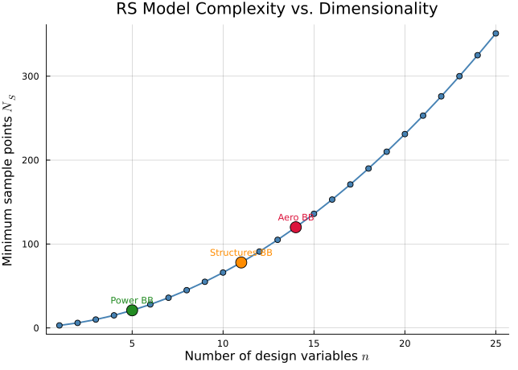

Figure 3.1: Minimum sample points required for a second-order RS vs. number of design variables. The quadratic growth illustrates the curse of dimensionality and motivates decomposition into smaller subproblems.

```julia
ns_vals = min_rs_points.(1:25)
n_vals  = 1:25

p = plot(n_vals, ns_vals,
    lw=2, color=:steelblue, marker=:circle, markersize=4,
    xlabel=L"Number of design variables $n$",
    ylabel=L"Minimum sample points $N_S$",
    title="RS Model Complexity vs. Dimensionality",
    legend=false, grid=true, gridalpha=0.3,
    xticks=0:5:25, yticks=0:100:400)

# Annotate BLISS-RS BBs
for (n_bb, label, color) in [(11,"Structures BB",:darkorange),
                               (14,"Aero BB",:crimson),
                               (5,"Power BB",:forestgreen)]
    ns = min_rs_points(n_bb)
    scatter!([n_bb], [ns], color=color, markersize=8, label="")
    annotate!(n_bb, ns + 12, text(label, 8, color))
end

p
```

This is the central computational motivation for the BLISS-RS architecture.

[1]

Altus, T. D., “A Response Surface Methodology for Bi-Level Integrated System Synthesis (BLISS),” NASA/CR-2002-211652, NASA Langley Research Center / George Washington University, Hampton, VA, 2002.

[2]

Sobieszczanski-Sobieski, J., Agte, J., and Sandusky, R., “Bi-Level Integrated System Synthesis,” 1998.

[3]

Sobieszczanski-Sobieski, J., Agte, J., and Sandusky, R., “Bi-Level Integrated System Synthesis (BLISS),” NASA/TM-1998-208715, NASA Langley Research Center, Hampton, VA, 2000.

[4]

Sobieszczanski-Sobieski, J., Emiley, M., Agte, J., and Sandusky, R., “Advancement of Bi-Level Integrated System Synthesis (BLISS),” 2000.